# PM566 Assignment 2

Echo Tang

2022-10-07

## Wrangling Data

### Step 1: Merging Data

We can merge the data on “townname,” as this is the only shared column across both the datasets.

```r
setwd("~/pm566/assignments")

library(tidyverse)
library(data.table)
```

```r
if (!file.exists("chs_individual.csv"))
  download.file(
    url = "https://raw.githubusercontent.com/USCbiostats/data-science-data/master/01_chs/chs_individual.csv",
    destfile = "chs_individual.csv",
    method   = "libcurl",
    timeout  = 60
    )
if (!file.exists("chs_regional.csv"))
  download.file(
    url = "https://raw.githubusercontent.com/USCbiostats/data-science-data/master/01_chs/chs_regional.csv",
    destfile = "chs_regional.csv",
    method   = "libcurl",
    timeout  = 60
    )
chs_regional = fread("chs_regional.csv")
chs_indiv = fread("chs_individual.csv")
```

```r
nrow(chs_regional)
```

```
## [1] 12
```

```r
nrow(chs_indiv)
```

```
## [1] 1200
```

```r
chs_merge = merge(x = chs_indiv, y = chs_regional, by.x = "townname",
    by.y = "townname")
dim(chs_merge)
```

```
## [1] 1200   49
```

There are 1200 rows in the individual dataset and in the merged dataset. Since they’re equal, this tells us that there are not duplicated observations in the merged dataset. Furthermore, there are 49 columns, which is what we expect.

```r
sum(colSums(is.na(chs_merge)))/(nrow(chs_merge)*ncol(chs_merge))
```

```
## [1] 0.02782313
```

NA values make up around 2.8% of the dataset. This is a very small part of the dataset, which is a good sign for us. However, we do have missing values in BMI, secondhand smoke, gas stove, asthma, and FEV in the dataset, which are our variables of interest. For BMI, FEV, and asthma variables, we can impute them using their respective means within the Hispanic and male variables.

```r
chs_merge[, bmi_imp := fcoalesce(bmi, mean(bmi, na.rm = TRUE)), by = .(hispanic, male)]

chs_merge[, fev_imp := fcoalesce(fev, mean(fev, na.rm = TRUE)), by = .(hispanic, male)]

chs_merge$asthma = as.double(chs_merge$asthma)
chs_merge[, asthma_imp := fcoalesce(asthma, mean(asthma, na.rm = TRUE)), by = .(hispanic, male)]
```

We want a four level categorical variable for secondhand smoke and gas exposure, so we need to impute missing values for those variables as well. Since they are boolean variables, I will impute using the most common value. We can find which secondhand smoke and gas stove option are the most common by using the sum() function.

```r
sum(chs_merge$smoke == 1, na.rm = T)
```

```
## [1] 190
```

```r
sum(chs_merge$smoke == 0, na.rm = T)
```

```
## [1] 970
```

```r
chs_merge[, smoke_imp := fcoalesce(smoke, as.integer(0)), by = .(hispanic, male)]

sum(chs_merge$gasstove == 1, na.rm = T)
```

```
## [1] 912
```

```r
sum(chs_merge$gasstove == 0, na.rm = T)
```

```
## [1] 255
```

```r
chs_merge[, gas_imp := fcoalesce(gasstove, as.integer(1)), by = .(hispanic, male)]

chs_merge = as_tibble(chs_merge)
```

### Step 2

We can create an obesity level categorical variable to investigate our research question.

```r
chs_merge = chs_merge %>%
  mutate(obesity_level = ifelse(
    chs_merge$bmi_imp < 14, 'Underweight', ifelse(
      chs_merge$bmi_imp >= 14 & chs_merge$bmi_imp < 22, 'Normal', ifelse(
        chs_merge$bmi_imp >= 22 & chs_merge$bmi_imp <= 24, 'Overweight', 'Obese'
        )
      )
    )
  )

chs_merge$obesity_level = as.factor(chs_merge$obesity_level)

obesity_summ = chs_merge %>%
  group_by(obesity_level) %>%
  summarise(min = min(bmi_imp),
            max = max(bmi_imp),
            count = n())

knitr::kable(obesity_summ)
```

| obesity_level | min | max | count |
| --- | --- | --- | --- |
| Normal | 14.00380 | 21.96387 | 975 |
| Obese | 24.00647 | 41.26613 | 103 |
| Overweight | 22.02353 | 23.99650 | 87 |
| Underweight | 11.29640 | 13.98601 | 35 |

There are 975 individuals in the normal category, 103 in the obese, 87 in the overweight, and 35 in the underweight. Added together, this is 1200, meaning that all observations were accounted for. The minimum and maximum of each obesity level also follow the cut-off values accordingly.

### Step 3

We can also create a categorical variable for smoke and gas exposure to investigate the research question.

```r
chs_merge = chs_merge %>%
  mutate(smoke_gas_exposure = ifelse(
    chs_merge$smoke_imp == 0 & chs_merge$gas_imp == 0, 'Neither', ifelse(
      chs_merge$smoke_imp == 0 & chs_merge$gas_imp == 1, 'Gas stove only', ifelse(
        chs_merge$smoke_imp == 1 & chs_merge$gas_imp == 0, 'Second-hand smoke only', 'Both'
      )
    )
  )
)

chs_merge$smoke_gas_exposure = as.factor(chs_merge$smoke_gas_exposure)
```

### Step 4

Below are four summary tables showing the mean FEV and asthma frequency (as a proportion) stratified by town name, sex, obesity level, and smoke/gas exposure. Summaries include the mean and standard deviation of FEV, the mean asthma frequency as a proportion, and sample size per categorical variable.

```r
# By town
town_summ = chs_merge %>%
  group_by(townname) %>%
  summarize(mean_fev = mean(fev_imp),
            sd_fev = sd(fev_imp),
            mean_asthma = mean(asthma_imp),
            count = n())

knitr::kable(town_summ)
```

| townname | mean_fev | sd_fev | mean_asthma | count |
| --- | --- | --- | --- | --- |
| Alpine | 2087.101 | 291.1768 | 0.1144423 | 100 |
| Atascadero | 2075.897 | 324.0935 | 0.2528408 | 100 |
| Lake Elsinore | 2038.849 | 303.6956 | 0.1274366 | 100 |
| Lake Gregory | 2084.700 | 319.9593 | 0.1512392 | 100 |
| Lancaster | 2003.044 | 317.1298 | 0.1640054 | 100 |
| Lompoc | 2034.354 | 351.0454 | 0.1142335 | 100 |
| Long Beach | 1985.861 | 319.4625 | 0.1359886 | 100 |
| Mira Loma | 1985.202 | 324.9634 | 0.1582359 | 100 |
| Riverside | 1989.881 | 277.5065 | 0.1100000 | 100 |
| San Dimas | 2026.794 | 318.7845 | 0.1712392 | 100 |
| Santa Maria | 2025.750 | 312.1725 | 0.1348240 | 100 |
| Upland | 2024.266 | 343.1637 | 0.1212392 | 100 |

```r
# By sex
sex_summ = chs_merge %>%
  group_by(male) %>%
  summarize(mean_fev = mean(fev_imp),
            sd_fev = sd(fev_imp),
            mean_asthma = mean(asthma_imp),
            count = n())

knitr::kable(sex_summ)
```

| male | mean_fev | sd_fev | mean_asthma | count |
| --- | --- | --- | --- | --- |
| 0 | 1958.911 | 311.9181 | 0.1208035 | 610 |
| 1 | 2103.787 | 307.5123 | 0.1726819 | 590 |

```r
# By obesity level
bmi_summ = chs_merge %>%
  group_by(obesity_level) %>%
  summarize(mean_fev = mean(fev_imp),
            sd_fev = sd(fev_imp),
            mean_asthma = mean(asthma_imp),
            count = n())

knitr::kable(bmi_summ)
```

| obesity_level | mean_fev | sd_fev | mean_asthma | count |
| --- | --- | --- | --- | --- |
| Normal | 1999.794 | 295.1964 | 0.1403606 | 975 |
| Obese | 2266.154 | 325.4710 | 0.2081964 | 103 |
| Overweight | 2224.322 | 317.4261 | 0.1640991 | 87 |
| Underweight | 1698.327 | 303.3983 | 0.0857143 | 35 |

```r
# By smoke and gas exposure
smoke_summ = chs_merge %>%
  group_by(smoke_gas_exposure) %>%
  summarize(mean_fev = mean(fev_imp),
            sd_fev = sd(fev_imp),
            mean_asthma = mean(asthma_imp),
            count = n())

knitr::kable(smoke_summ)
```

| smoke_gas_exposure | mean_fev | sd_fev | mean_asthma | count |
| --- | --- | --- | --- | --- |
| Both | 2024.778 | 300.6313 | 0.1277738 | 154 |
| Gas stove only | 2022.671 | 319.3449 | 0.1491750 | 791 |
| Neither | 2056.693 | 328.7843 | 0.1448168 | 219 |
| Second-hand smoke only | 2055.714 | 295.6475 | 0.1717490 | 36 |

## Looking at Data

#### Check dimensions

```r
dim(chs_merge)
```

```
## [1] 1200   56
```

The merged dataset has 1200 observations and 56 variables. The added 7 variables are from the FEV, BMI, asthma, second-hand smoke, and gas stove imputed variables along with the obesity level and smoke/gas exposure factor variables.

#### Check headers and footers, column names

```r
head(chs_merge) %>% knitr::kable()
```

| townname | sid | male | race | hispanic | agepft | height | weight | bmi | asthma | active_asthma | father_asthma | mother_asthma | wheeze | hayfever | allergy | educ_parent | smoke | pets | gasstove | fev | fvc | mmef | pm25_mass | pm25_so4 | pm25_no3 | pm25_nh4 | pm25_oc | pm25_ec | pm25_om | … |
| --- | --- | --- | --- | --- | --- | --- | --- | --- | --- | --- | --- | --- | --- | --- | --- | --- | --- | --- | --- | --- | --- | --- | --- | --- | --- | --- | --- | --- | --- | --- |
| Alpine | 835 | 0 | W | 0 | 10.099932 | 143 | 69 | 15.33749 | 0 | 0 | 0 | 0 | 0 | 0 | 1 | 3 | 0 | 1 | 0 | 2529.276 | 2826.316 | 3406.579 | 8.74 | 1.73 | 1.59 | 0.88 | 2.54 | 0.48 | 3.04 | … |
| Alpine | 838 | 0 | O | 1 | 9.486653 | 133 | 62 | 15.93183 | 0 | 0 | 0 | 0 | 0 | 0 | 0 | 4 | NA | 1 | 0 | 1737.793 | 1963.545 | 2133.110 | 8.74 | 1.73 | 1.59 | 0.88 | 2.54 | 0.48 | 3.04 | … |
| Alpine | 839 | 0 | M | 1 | 10.053388 | 142 | 86 | 19.38649 | 0 | 0 | 0 | 1 | 1 | 1 | 1 | 3 | 1 | 1 | 0 | 2121.711 | 2326.974 | 2835.197 | 8.74 | 1.73 | 1.59 | 0.88 | 2.54 | 0.48 | 3.04 | … |
| Alpine | 840 | 0 | W | 0 | 9.965777 | 146 | 78 | 16.63283 | 0 | 0 | 0 | 0 | 0 | 0 | 0 | NA | NA | 0 | NA | 2466.791 | 2638.221 | 3466.464 | 8.74 | 1.73 | 1.59 | 0.88 | 2.54 | 0.48 | 3.04 | … |
| Alpine | 841 | 1 | W | 1 | 10.548939 | 150 | 78 | 15.75758 | 0 | 0 | 0 | 0 | 0 | 0 | 0 | 5 | 0 | 1 | 0 | 2251.505 | 2594.649 | 2445.151 | 8.74 | 1.73 | 1.59 | 0.88 | 2.54 | 0.48 | 3.04 | … |
| Alpine | 842 | 1 | M | 1 | 9.489391 | 139 | 65 | 15.29189 | 0 | 0 | 0 | 0 | 1 | 0 | 0 | 1 | 1 | 1 | 0 | 2188.716 | 2423.934 | 2524.599 | 8.74 | 1.73 | 1.59 | 0.88 | 2.54 | 0.48 | 3.04 | … |

```r
tail(chs_merge) %>% knitr::kable()
```

| townname | sid | male | race | hispanic | agepft | height | weight | bmi | asthma | active_asthma | father_asthma | mother_asthma | wheeze | hayfever | allergy | educ_parent | smoke | pets | gasstove | fev | fvc | mmef | pm25_mass | pm25_so4 | pm25_no3 | pm25_nh4 | pm25_oc | pm25_ec | pm25_om | … |
| --- | --- | --- | --- | --- | --- | --- | --- | --- | --- | --- | --- | --- | --- | --- | --- | --- | --- | --- | --- | --- | --- | --- | --- | --- | --- | --- | --- | --- | --- | --- |
| Upland | 1866 | 0 | O | 1 | 9.806981 | 139 | 60 | 14.11559 | 0 | 0 | NA | 0 | 0 | NA | NA | 3 | 0 | 1 | 0 | 1691.275 | 1928.859 | 1890.604 | 22.46 | 2.65 | 7.75 | 2.96 | 6.49 | 1.19 | 7.79 | … |
| Upland | 1867 | 0 | M | 1 | 9.618070 | 140 | 71 | 16.46568 | 0 | 0 | 1 | 0 | 0 | 0 | 0 | 3 | 0 | 1 | 0 | 1733.338 | 1993.040 | 2072.643 | 22.46 | 2.65 | 7.75 | 2.96 | 6.49 | 1.19 | 7.79 | … |
| Upland | 2031 | 1 | W | 0 | 9.798768 | 135 | 83 | 20.70084 | 0 | 0 | 0 | 0 | 1 | 0 | 1 | 3 | 0 | 1 | 1 | 2034.177 | 2505.535 | 1814.075 | 22.46 | 2.65 | 7.75 | 2.96 | 6.49 | 1.19 | 7.79 | … |
| Upland | 2032 | 1 | W | 0 | 9.549623 | 137 | 59 | 14.28855 | 0 | 0 | 0 | 1 | 1 | 1 | 1 | 3 | 0 | 1 | 1 | 2077.703 | 2275.338 | 2706.081 | 22.46 | 2.65 | 7.75 | 2.96 | 6.49 | 1.19 | 7.79 | … |
| Upland | 2033 | 0 | M | 0 | 10.121834 | 130 | 67 | 18.02044 | 0 | 1 | 0 | 0 | 1 | 1 | 0 | 3 | 0 | 1 | 1 | 1929.866 | 2122.148 | 2558.054 | 22.46 | 2.65 | 7.75 | 2.96 | 6.49 | 1.19 | 7.79 | … |
| Upland | 2053 | 0 | W | 0 | NA | NA | NA | NA | 0 | 0 | 0 | 0 | 0 | 0 | 0 | 3 | 0 | 1 | 0 | NA | NA | NA | 22.46 | 2.65 | 7.75 | 2.96 | 6.49 | 1.19 | 7.79 | … |

```r
colnames(chs_merge)
```

```
##  [1] "townname"           "sid"                "male"
##  [4] "race"               "hispanic"           "agepft"
##  [7] "height"             "weight"             "bmi"
## [10] "asthma"             "active_asthma"      "father_asthma"
## [13] "mother_asthma"      "wheeze"             "hayfever"
## [16] "allergy"            "educ_parent"        "smoke"
## [19] "pets"               "gasstove"           "fev"
## [22] "fvc"                "mmef"               "pm25_mass"
## [25] "pm25_so4"           "pm25_no3"           "pm25_nh4"
## [28] "pm25_oc"            "pm25_ec"            "pm25_om"
## [31] "pm10_oc"            "pm10_ec"            "pm10_tc"
## [34] "formic"             "acetic"             "hcl"
## [37] "hno3"               "o3_max"             "o3106"
## [40] "o3_24"              "no2"                "pm10"
## [43] "no_24hr"            "pm2_5_fr"           "iacid"
## [46] "oacid"              "total_acids"        "lon"
## [49] "lat"                "bmi_imp"            "fev_imp"
## [52] "asthma_imp"         "smoke_imp"          "gas_imp"
## [55] "obesity_level"      "smoke_gas_exposure"
```

#### Check variable types

```r
str(chs_merge)
```

```
## tibble [1,200 × 56] (S3: tbl_df/tbl/data.frame)
##  $ townname          : chr [1:1200] "Alpine" "Alpine" "Alpine" "Alpine" ...
##  $ sid               : int [1:1200] 835 838 839 840 841 842 843 844 847 849 ...
##  $ male              : int [1:1200] 0 0 0 0 1 1 1 1 1 1 ...
##  $ race              : chr [1:1200] "W" "O" "M" "W" ...
##  $ hispanic          : int [1:1200] 0 1 1 0 1 1 0 1 0 0 ...
##  $ agepft            : num [1:1200] 10.1 9.49 10.05 9.97 10.55 ...
##  $ height            : int [1:1200] 143 133 142 146 150 139 149 143 137 147 ...
##  $ weight            : int [1:1200] 69 62 86 78 78 65 98 65 69 112 ...
##  $ bmi               : num [1:1200] 15.3 15.9 19.4 16.6 15.8 ...
##  $ asthma            : num [1:1200] 0 0 0 0 0 0 0 NA 0 0 ...
##  $ active_asthma     : int [1:1200] 0 0 0 0 0 0 0 0 0 0 ...
##  $ father_asthma     : int [1:1200] 0 0 0 0 0 0 0 NA 0 1 ...
##  $ mother_asthma     : int [1:1200] 0 0 1 0 0 0 0 NA 0 0 ...
##  $ wheeze            : int [1:1200] 0 0 1 0 0 1 1 NA 0 1 ...
```

[output cut: 44 more lines]

```r
summary(chs_merge)
```

```
##    townname              sid              male            race
##  Length:1200        Min.   :   1.0   Min.   :0.0000   Length:1200
##  Class :character   1st Qu.: 528.8   1st Qu.:0.0000   Class :character
##  Mode  :character   Median :1041.5   Median :0.0000   Mode  :character
##                     Mean   :1037.5   Mean   :0.4917
##                     3rd Qu.:1554.2   3rd Qu.:1.0000
##                     Max.   :2053.0   Max.   :1.0000
##
##     hispanic          agepft           height        weight
##  Min.   :0.0000   Min.   : 8.961   Min.   :114   Min.   : 42.00
##  1st Qu.:0.0000   1st Qu.: 9.610   1st Qu.:135   1st Qu.: 65.00
##  Median :0.0000   Median : 9.906   Median :139   Median : 74.00
##  Mean   :0.4342   Mean   : 9.924   Mean   :139   Mean   : 79.33
##  3rd Qu.:1.0000   3rd Qu.:10.177   3rd Qu.:143   3rd Qu.: 89.00
##  Max.   :1.0000   Max.   :12.731   Max.   :165   Max.   :207.00
##                   NA's   :89       NA's   :89    NA's   :89
##       bmi            asthma       active_asthma  father_asthma
##  Min.   :11.30   Min.   :0.0000   Min.   :0.00   Min.   :0.00000
##  1st Qu.:15.78   1st Qu.:0.0000   1st Qu.:0.00   1st Qu.:0.00000
##  Median :17.48   Median :0.0000   Median :0.00   Median :0.00000
##  Mean   :18.50   Mean   :0.1463   Mean   :0.19   Mean   :0.08318
##  3rd Qu.:20.35   3rd Qu.:0.0000   3rd Qu.:0.00   3rd Qu.:0.00000
##  Max.   :41.27   Max.   :1.0000   Max.   :1.00   Max.   :1.00000
##  NA's   :89      NA's   :31                      NA's   :106
##  mother_asthma        wheeze          hayfever         allergy
##  Min.   :0.0000   Min.   :0.0000   Min.   :0.0000   Min.   :0.0000
##  1st Qu.:0.0000   1st Qu.:0.0000   1st Qu.:0.0000   1st Qu.:0.0000
##  Median :0.0000   Median :0.0000   Median :0.0000   Median :0.0000
##  Mean   :0.1023   Mean   :0.3313   Mean   :0.1747   Mean   :0.2929
##  3rd Qu.:0.0000   3rd Qu.:1.0000   3rd Qu.:0.0000   3rd Qu.:1.0000
##  Max.   :1.0000   Max.   :1.0000   Max.   :1.0000   Max.   :1.0000
##  NA's   :56       NA's   :71       NA's   :118      NA's   :63
##   educ_parent        smoke             pets           gasstove
##  Min.   :1.000   Min.   :0.0000   Min.   :0.0000   Min.   :0.0000
##  1st Qu.:2.000   1st Qu.:0.0000   1st Qu.:1.0000   1st Qu.:1.0000
##  Median :3.000   Median :0.0000   Median :1.0000   Median :1.0000
##  Mean   :2.797   Mean   :0.1638   Mean   :0.7667   Mean   :0.7815
##  3rd Qu.:3.000   3rd Qu.:0.0000   3rd Qu.:1.0000   3rd Qu.:1.0000
##  Max.   :5.000   Max.   :1.0000   Max.   :1.0000   Max.   :1.0000
##  NA's   :64      NA's   :40                        NA's   :33
```

[output cut: 65 more lines]

```
##  Min.   :0.0000   Min.   :0.0000   Normal     :975
##  1st Qu.:0.0000   1st Qu.:1.0000   Obese      :103
##  Median :0.0000   Median :1.0000   Overweight : 87
##  Mean   :0.1583   Mean   :0.7875   Underweight: 35
##  3rd Qu.:0.0000   3rd Qu.:1.0000
##  Max.   :1.0000   Max.   :1.0000
##
##               smoke_gas_exposure
##  Both                  :154
##  Gas stove only        :791
##  Neither               :219
##  Second-hand smoke only: 36
##
##
##
```

From the summary, we can see that the imputed variables, all denoted with *_imp, have no more NA values. Accordingly, the categorical variables obesity_level and smoke_gas_exposure using columns with imputed data have no NA values, signifying that the data was imputed correctly. We can also see that our other variable of interest, pm25_mass, has no missing values.

#### Check variables of interest

```r
table(chs_merge$bmi_imp)
```

```
##
## 11.2963959117805 12.1182060545939 12.3113218351314  12.593299396006
##                1                1                1                1
## 12.6572024544847 12.7040290592902 12.7618963068182 12.9786884638001
##                1                1                1                1
##  12.987012987013 13.0072840790843 13.0436597378746 13.3167613636364
##                1                1                1                1
##  13.362181941525 13.3818181818182 13.3842481057192 13.4480903711673
##                1                1                1                3
## 13.4680134680135 13.5254549061333 13.5620147341603 13.6573960262441
##                1                2                1                1
## 13.6697786508435 13.7170521785906  13.717985650987 13.7733020432164
##                1                1                1                1
## 13.8761120161991 13.8803280462615 13.9146567717996 13.9305439467689
##                2                1                1                2
## 13.9668287816436  13.986013986014 14.0037965848519 14.0525348610961
##                1                1                1                1
## 14.0739350722462   14.08222107655 14.1155878436558 14.1271277706573
##                1                1                4                2
## 14.1760667490229   14.20172765144 14.2260790703257 14.2549757934373
##                3                1                1                1
##  14.268727705113 14.2871765127348  14.288551237776 14.3030444294939
##                1                2                4                1
## 14.3186798592204 14.3480257116621   14.35084764105  14.378478664193
##                1                1                1                1
## 14.3900420908731 14.4271518998756 14.4292107981126 14.4483615557996
##                3                1                1                2
## 14.4656440952737 14.4768397878187 14.4994495124253 14.5239376008607
##                3                1                2                3
## 14.5307300723146 14.5366097350242 14.5679156226327 14.5861074384443
##                3                1                1                1
## 14.6325180277195 14.6525761483111  14.654574763695 14.6706440412734
##                1                1                2                1
## 14.6823548472022 14.6867985409652 14.7136593937119 14.7413507172077
##                2                1                1                1
## 14.7452028939918 14.7499877083436 14.7729089068532 14.7810046353231
##                4                1                2                2
##  14.792899408284 14.7982662160356 14.8327868157715 14.8363636363636
##                1                2                2                1
## 14.8423005565863 14.8611511219026 14.8697721011771 14.8780003967467
```

[output cut: 300 more lines]

```
##                2                1                1                1
## 27.8819209416023 27.9369176529841 27.9765585888035 28.0583613916947
##                1                1                1                1
## 28.3496246587365 28.7159792368126 28.7569573283859 28.8967231115991
##                1                1                1                1
## 29.0732194700484 29.5110872033949 29.6184196303102 29.6749452154858
##                1                1                1                1
## 29.9030287496262 30.6749829953899 30.9090909090909 30.9155766944114
##                1                1                1                1
## 31.3418304518114  31.346450617284 32.3939099449304 33.2027359054386
##                1                1                1                1
## 34.1414141414141 34.3228200371058 34.8628727007105 40.2221662609474
##                1                1                1                1
## 41.2661326656327
##                1
```

```r
summary(chs_merge$bmi_imp)
```

```
##    Min. 1st Qu.  Median    Mean 3rd Qu.    Max.
##   11.30   15.96   17.81   18.50   19.99   41.27
```

```r
table(chs_merge$obesity_level)
```

```
##
##      Normal       Obese  Overweight Underweight
##         975         103          87          35
```

```r
summary(chs_merge$obesity_level)
```

```
##      Normal       Obese  Overweight Underweight
##         975         103          87          35
```

```r
table(chs_merge$fev_imp)
```

```
##
## 984.848484848485 995.959595959596             1032 1110.40268456376
##                1                1                1                1
## 1146.44941315324 1168.79194630872 1210.03344481605 1215.35836177474
##                1                1                1                1
## 1225.25252525253             1281   1288.289136023  1295.8849009901
##                1                1                1                1
## 1303.34448160535 1315.38461538462 1316.97850993153 1332.55813953488
##                1                1                1                1
## 1334.34343434343 1336.94941760138 1360.34249226006 1373.15436241611
##                1                1                1                1
## 1379.79797979798 1381.94608901581 1385.47297297297 1391.72185430464
##                1                1                1                1
## 1394.35215946844 1408.82352941176 1416.16161616162 1427.90319300386
##                1                1                1                1
## 1428.71287128713             1435 1437.41721854305 1441.19007295466
##                1                1                1                1
## 1444.59634551495 1448.59768211921 1454.12175445733 1462.62626262626
##                1                1                1                1
## 1466.55405405405             1476 1476.07973421927 1477.22772277228
##                1                1                1                1
## 1478.85906040268 1479.92488851728 1488.15789473684 1491.52649006623
##                1                1                1                1
##             1492 1492.59054194893 1492.95302013423             1498
##                1                1                1                1
## 1500.99500557414             1505 1510.59250220324             1511
##                1                1                1                1
## 1512.08053691275 1513.86138613861  1515.8940397351 1515.92739273927
##                1                1                1                1
## 1522.77227722772 1525.53833333333  1526.1744966443 1530.18428318107
##                1                1                1                1
## 1531.76903260796 1533.44262295082 1539.86710963455             1544
##                1                1                1                1
## 1544.70198675497 1545.39473684211  1549.3288590604 1549.49494949495
##                1                1                1                1
##  1558.6248921484 1561.98773850895 1564.82851114453 1566.11842105263
##                1                1                1                1
## 1571.28712871287 1573.64512767066 1573.73737373737  1574.2474916388
##                1                1                1                1
## 1576.25479261067 1579.20792079208 1581.63265306122 1584.49017199017
```

[output cut: 488 more lines]

```
##                1                1                1                1
## 2730.10033444816 2730.39215686275 2761.79401993356 2763.97449347584
##                1                1                1                1
## 2779.20792079208 2791.80302959465 2801.67785234899 2825.74257425743
##                1                1                1                1
##             2830             2832 2834.21052631579 2839.46488294314
##                1                1                1                1
## 2857.95720448663 2871.77329594478 2877.43779312142 2879.59866220736
##                1                1                1                1
## 2904.31893687708 2912.17105263158 2921.47651006711 2939.40397350993
##                1                1                1                1
## 2959.45945945946  3004.0379592595             3060 3179.79797979798
##                1                1                1                1
## 3283.37061894109 3323.68421052632
##                1                1
```

```r
summary(chs_merge$fev_imp)
```

```
##    Min. 1st Qu.  Median    Mean 3rd Qu.    Max.
##   984.8  1827.6  2016.4  2030.1  2223.6  3323.7
```

```r
table(chs_merge$smoke_gas_exposure)
```

```
##
##                   Both         Gas stove only                Neither
##                    154                    791                    219
## Second-hand smoke only
##                     36
```

```r
summary(chs_merge$smoke_gas_exposure)
```

```
##                   Both         Gas stove only                Neither
##                    154                    791                    219
## Second-hand smoke only
##                     36
```

```r
table(chs_merge$pm25_mass)
```

```
##
##  5.96  7.19  7.48  7.66   8.5  8.74 12.35 19.12 20.52 22.39 22.46 29.97
##   100   100   100   100   100   100   100   100   100   100   100   100
```

```r
summary(chs_merge$pm25_mass)
```

```
##    Min. 1st Qu.  Median    Mean 3rd Qu.    Max.
##   5.960   7.615  10.545  14.362  20.988  29.970
```

```r
chs_merge$townname[chs_merge$bmi_imp > 40]
```

```
## [1] "Riverside" "Riverside"
```

We can see that both of these very high BMIs come from Riverside. There doesn’t seem to be information correlating this location with high BMI, but this is just an observation from this data in particular. Next, let’s look at FEV and PM2.5 mass and their distributions.

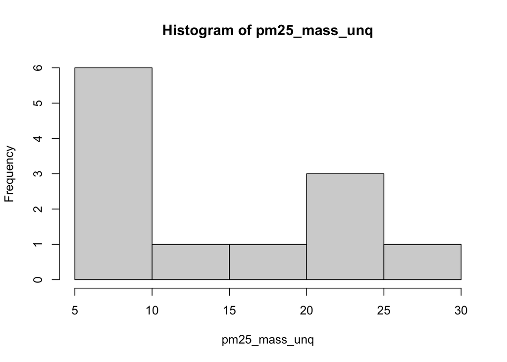

```r
pm25_mass_unq = unique(chs_merge$pm25_mass)

hist(pm25_mass_unq)
```

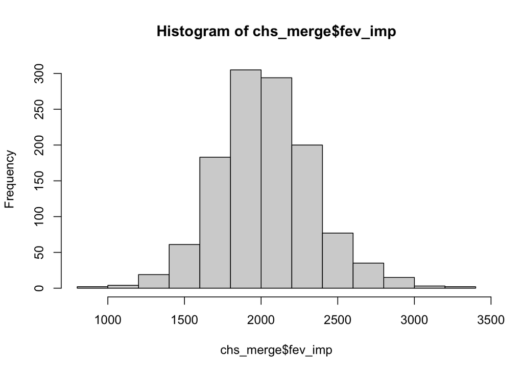

```r
hist(chs_merge$fev_imp)
```

From these histograms, we can see that the FEV values are normally distributed, so we can proceed with the FEV data. However, the histogram for PM2.5 mass is not normally distributed, with most PM2.5 values being low from 5-10. Validating with information online, PM2.5 mass usually varies between 5 and 35, given the levels are not dangerous. This corroborates what the table() function and histogram shows us, so we can proceed with the PM2.5 mass data as well.

### Visualization

##### Facet scatter plots of BMI vs. FEV

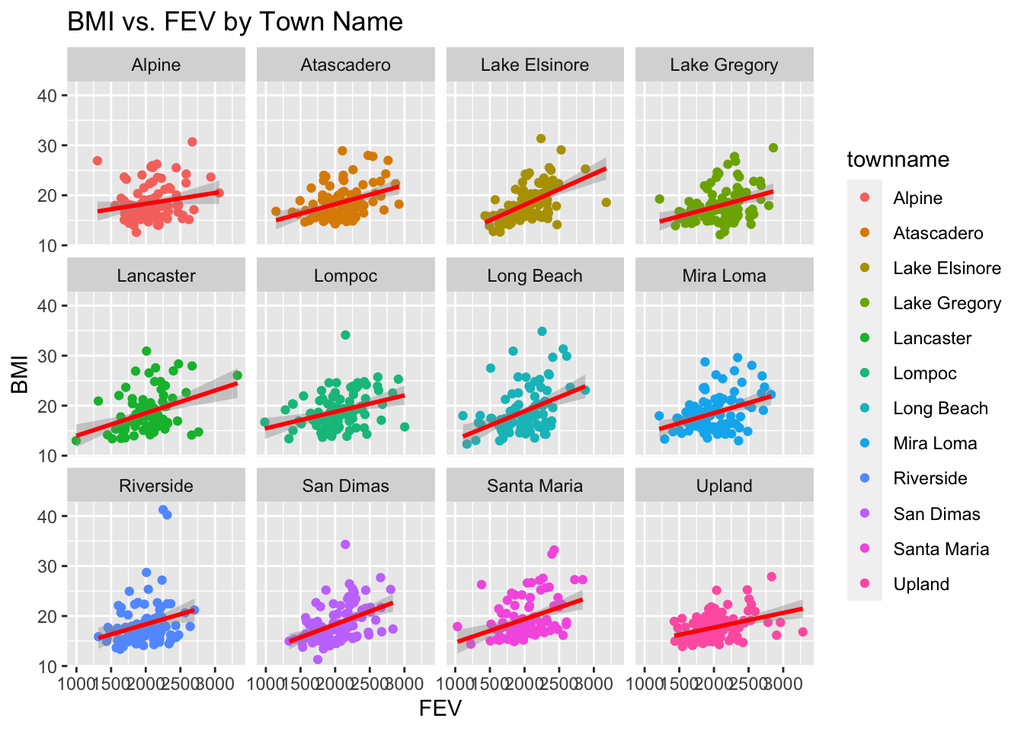

```r
chs_merge %>% ggplot(mapping = aes(x = fev_imp, y = bmi_imp, color = townname)) + geom_point() + geom_smooth(method = lm, color = "red") + facet_wrap(~ townname) + xlab("FEV") + ylab("BMI") + ggtitle("BMI vs. FEV by Town Name")
```

##### Stacked Histograms

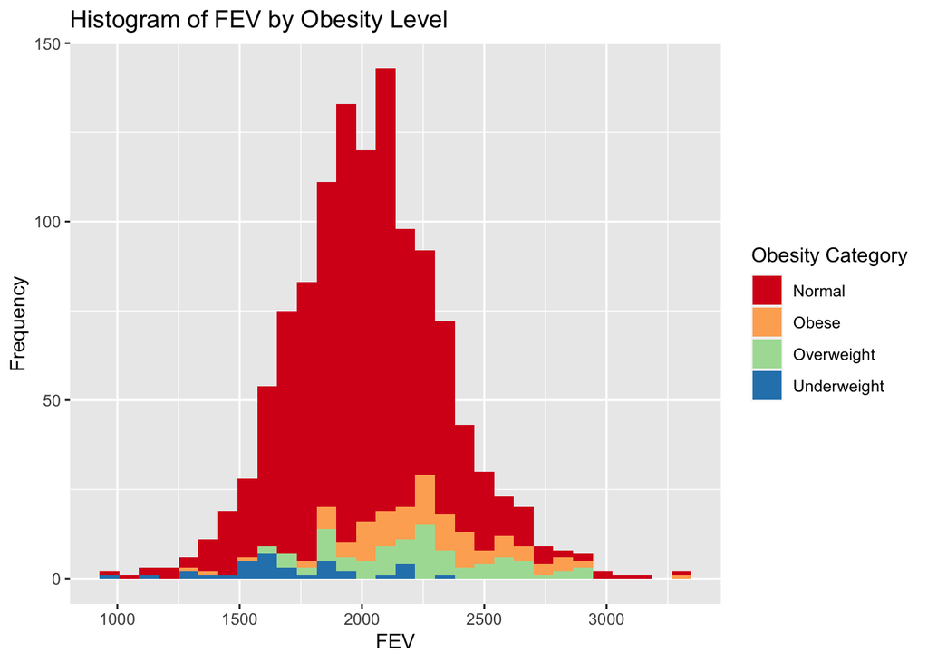

```r
chs_merge %>% ggplot(mapping = aes(x = fev_imp, fill = obesity_level)) + geom_histogram() + scale_fill_brewer(palette="Spectral") + xlab('FEV') + ylab("Frequency") + guides(fill = guide_legend(title = "Obesity Category")) + ggtitle("Histogram of FEV by Obesity Level")
```

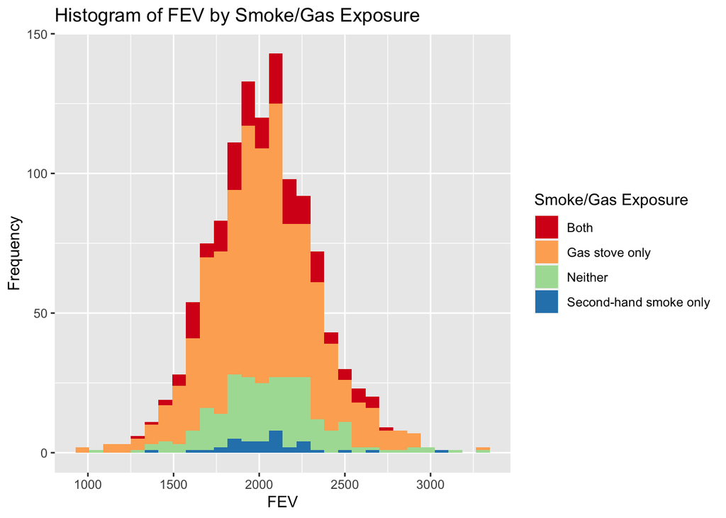

```r
chs_merge %>% ggplot(mapping = aes(x = fev_imp, fill = smoke_gas_exposure)) + geom_histogram() + scale_fill_brewer(palette="Spectral") + xlab('FEV') + ylab("Frequency") + guides(fill = guide_legend(title = "Smoke/Gas Exposure")) + ggtitle("Histogram of FEV by Smoke/Gas Exposure")
```

We can see here that the distribution of FEV is shifted based on obesity level. All obesity levels’ FEV distributions look relatively normal, but centered at different values. The “normal” BMI is centered at around an FEV of 1800-2100, whereas the “underweight” group’s FEV has most of its values between 1500-2000. However, it is important to note that the underweight category had the least observations, which can also affect its distribution in this dataset. On the other hand, both the obese and overweight groups’ FEV distributions are centered around 2000-2500. From this stacked histogram, we can see that there are some differences between each obesity group’s corresponding FEV distributions.

On the other hand, the distributions for all the smoke and gas exposure groups seem to be overlapping. Similarly, though they do also follow normal distributions, we don’t see as much of a difference in where these distributions are centered based on their smoke and gas exposure. From this stacked histogram, there isn’t very compelling evidence that FEV differs based on smoke and gas exposure.

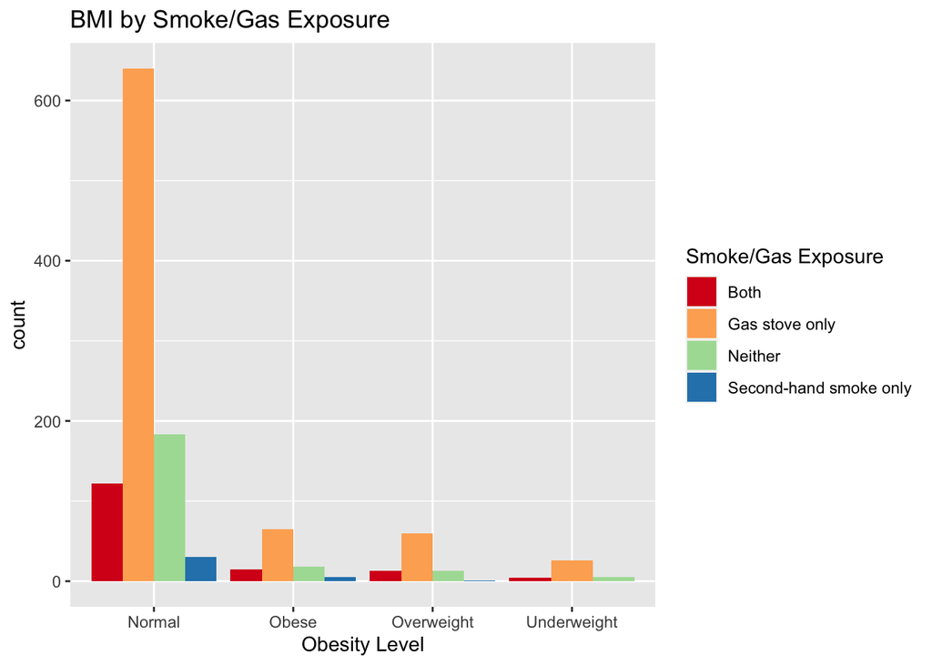

```r
chs_merge %>% ggplot(mapping = aes(x = obesity_level, fill = smoke_gas_exposure)) + geom_bar(position = "dodge") + scale_fill_brewer(palette="Spectral") + xlab("Obesity Level") + ggtitle("BMI by Smoke/Gas Exposure") + guides(fill = guide_legend(title = "Smoke/Gas Exposure"))
```

#### Summary Graphs

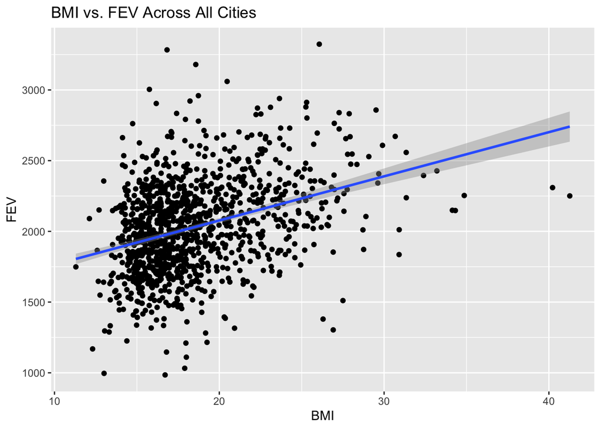

```r
chs_merge %>% ggplot(mapping = aes(x = bmi_imp, y = fev_imp)) + geom_point() + geom_smooth(method = lm) + xlab("BMI") + ylab("FEV") + ggtitle("BMI vs. FEV Across All Cities")
```

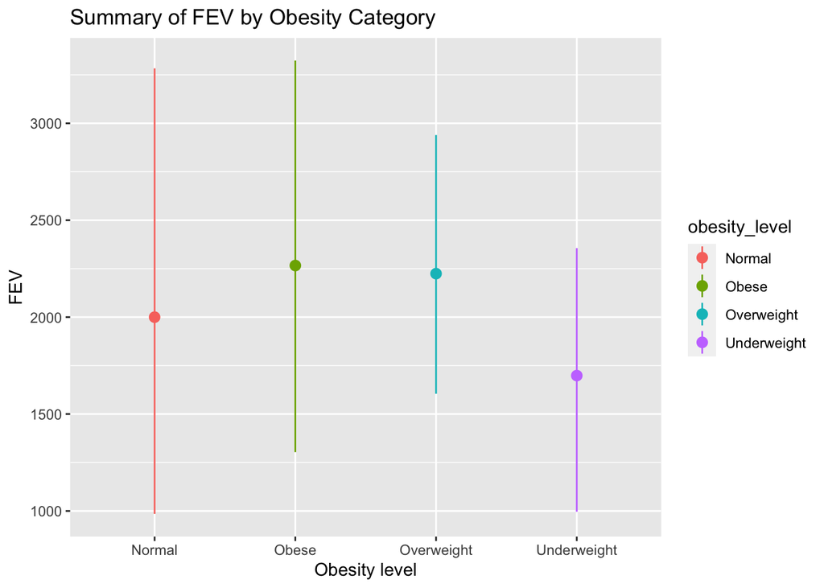

```r
fev_bmi = chs_merge %>% group_by(obesity_level)
chs_merge %>% ggplot() + stat_summary(mapping = aes(x = obesity_level, y = fev_imp, color = obesity_level), fun.min = min, fun.max = max, fun = mean, na.rm = TRUE) + xlab("Obesity level") + ylab("FEV") + ggtitle("Summary of FEV by Obesity Category")
```

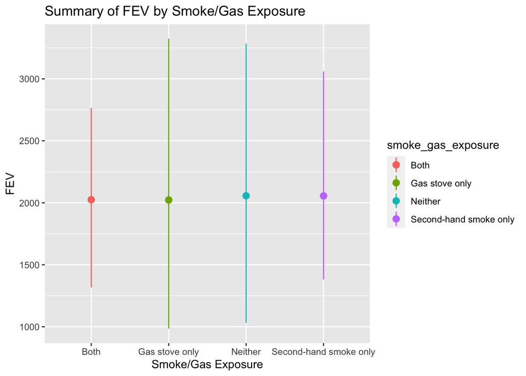

```r
fev_gas = chs_merge %>% group_by(smoke_gas_exposure)
fev_gas %>% ggplot() + stat_summary(mapping = aes(x = smoke_gas_exposure, y = fev_imp, color = smoke_gas_exposure), fun.min = min, fun.max = max, fun = mean, na.rm = TRUE) + xlab("Smoke/Gas Exposure") + ylab("FEV") + ggtitle("Summary of FEV by Smoke/Gas Exposure")
```

Contrasting the relationship between BMI and mean FEV, the smoke and gas exposure does not seem to have a big effect on mean FEV. As demonstrated by the bar graph, the mean FEV between all groups are around 2000. However, the distributions differ across groups; the distribution of FEV for those with both exposures and second-hand smoke only is much smaller compared to the gas stove only and neither exposures groups.

#### Leaflet Map

We can visualize PM2.5 mass based on location.

```r
library(leaflet)
pm.pal = colorNumeric(c('darkgreen', 'goldenrod', 'brown'), domain = chs_merge$pm25_mass)

pm_map <- leaflet(chs_merge) %>%
  addProviderTiles('CartoDB.Positron') %>%
  addCircles(
    lat = ~lat, lng = ~lon,
    label = ~paste0(pm25_mass), color = ~ pm.pal(pm25_mass),
    opacity = 1, fillOpacity = 1, radius = 50
    ) %>%
  addLegend('bottomleft', pal=pm.pal, values=chs_merge$pm25_mass,
          title='PM2.5 Mass', opacity=1)

pm_map
```

[interactive chart not shown]

We can see that the site with the highest PM2.5 mass is one of the more eastern sites. We can extract this value.

```r
unique(chs_merge$townname[chs_merge$pm25_mass == max(chs_merge$pm25_mass)])
```

```
## [1] "Mira Loma"
```

Mira Loma has the highest PM2.5 mass in this dataset. With validation for the Internet, Mira Loma is one of the most polluted cities in Southern California in terms of PM2.5 pollution due to its proximity to the Ontario Freeway. This is supported by the data from this dataset.

```r
unique(chs_merge$townname[chs_merge$pm25_mass > mean(chs_merge$pm25_mass)])
```

```
## [1] "Long Beach" "Mira Loma"  "Riverside"  "San Dimas"  "Upland"
```

Other cities with higher than average PM2.5 mass are Long Beach, Riverside, San Dimas, and Upland. Similarly to Mira Loma, these cities are near freeways. Long Beach, in particular, is a very busy port city, which can also contribute to its higher PM2.5 mass. The other sites with lower PM2.5 values are nearer to the coast or further inland, away from urban centers with a lot of automobile traffic.

Lastly, let’s visualize if FEV and PM2.5 mass are related or not. We can use a scatterplot to see this relationship since FEV and PM2.5 mass are both continuous variables.

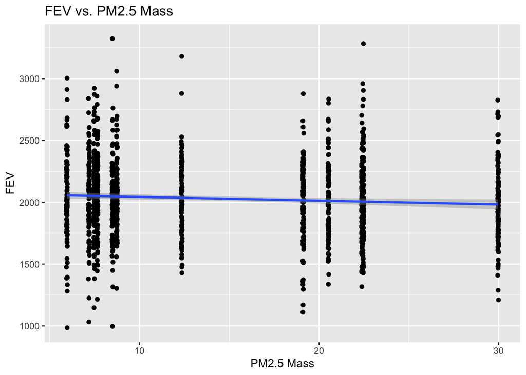

```r
chs_merge %>% ggplot(mapping = aes(x = pm25_mass, y = fev_imp)) + geom_jitter() + geom_smooth(method = lm) + xlab("PM2.5 Mass") + ylab("FEV") + ggtitle("FEV vs. PM2.5 Mass")
```

We can see there is a slight negative relationship with FEV and PM2.5 mass.